# Tranx User Study Data Analysis

### Correlation between participants’ python expertise and programming expertise

```r
cor.test(completion_times$programming_experience, completion_times$python_experience, method = "spearman")
```

```
##
##  Spearman's rank correlation rho
##
## data:  completion_times$programming_experience and completion_times$python_experience
## S = 582661, p-value < 2.2e-16
## alternative hypothesis: true rho is not equal to 0
## sample estimates:
##       rho
## 0.6930781
```

```r
cor.test(scores$programming_experience, scores$python_experience, method = "spearman")
```

```
##
##  Spearman's rank correlation rho
##
## data:  scores$programming_experience and scores$python_experience
## S = 704153, p-value < 2.2e-16
## alternative hypothesis: true rho is not equal to 0
## sample estimates:
##       rho
## 0.6826192
```

## Task completion times

### Descriptives

Number of entries in each group (plugin = 1):

```r
table(completion_times$use_plugin)
```

```
##
## FALSE  TRUE
##   106   119
```

Summary statistics for the two distributions (plugin, no plugin):

```r
summary(completion_times[completion_times$use_plugin == 1,]$completion_time)
```

```
##    Min. 1st Qu.  Median    Mean 3rd Qu.    Max.
##      36    1054    1698    2510    3136    9900
```

```r
summary(completion_times[completion_times$use_plugin == 0,]$completion_time)
```

```
##    Min. 1st Qu.  Median    Mean 3rd Qu.    Max.
##     211    1057    2240    2817    3714    9986
```

Visualize the two groups:

```r
pdf('figures/completion_all.pdf', pointsize = 18)
plugin = completion_times[completion_times$use_plugin == 1,]$completion_time
no_plugin = completion_times[completion_times$use_plugin == 0,]$completion_time
boxplot(list(plugin = plugin,
             no_plugin = no_plugin),
        names = c(paste("plugin (", length(plugin), ")", sep = ""),
                    paste("no_plugin (", length(no_plugin), ")", sep = ""))
        )
dev.off()
```

The two groups are statistically indistinguishable:

```r
t.test(completion_times[completion_times$use_plugin == 1,]$completion_time,
       completion_times[completion_times$use_plugin == 0,]$completion_time)
```

```
##
##  Welch Two Sample t-test
##
## data:  completion_times[completion_times$use_plugin == 1, ]$completion_time and completion_times[completion_times$use_plugin == 0, ]$completion_time
## t = -1.0264, df = 213.46, p-value = 0.3058
## alternative hypothesis: true difference in means is not equal to 0
## 95 percent confidence interval:
##  -898.5202  283.1755
## sample estimates:
## mean of x mean of y
##  2509.790  2817.462
```

Visualize the two groups separately for each task:

```r
for (cate in sort(unique(completion_times$category))) {
  plugin = completion_times[completion_times$category == cate &
                              completion_times$use_plugin == 1,]$completion_time
  no_plugin = completion_times[completion_times$category == cate &
                                 completion_times$use_plugin == 0,]$completion_time
  pdf(paste0('figures/completion_', cate, '.pdf'), pointsize = 18)
  boxplot(list(plugin = plugin,
               no_plugin = no_plugin),
          names = c(paste("plugin (", length(plugin), ")", sep = ""),
                    paste("no_plugin (", length(no_plugin), ")", sep = "")))
  dev.off()
}
```

Test the two groups separately for each task:

```r
for (cate in sort(unique(completion_times$category))) {
  plugin = completion_times[completion_times$category == cate &
                              completion_times$use_plugin == 1,]$completion_time
  no_plugin = completion_times[completion_times$category == cate &
                                 completion_times$use_plugin == 0,]$completion_time
  if (length(plugin) > 10){
    show(cate)
    show(t.test(plugin, no_plugin))
  }
}
```

```
## [1] "task1"
##
##  Welch Two Sample t-test
##
## data:  plugin and no_plugin
## t = 0.40992, df = 54.675, p-value = 0.6835
## alternative hypothesis: true difference in means is not equal to 0
## 95 percent confidence interval:
##  -597.8945  905.3320
## sample estimates:
## mean of x mean of y
##  1817.719  1664.000
##
## [1] "task2"
##
##  Welch Two Sample t-test
##
## data:  plugin and no_plugin
## t = -1.6504, df = 42.449, p-value = 0.1062
## alternative hypothesis: true difference in means is not equal to 0
## 95 percent confidence interval:
##  -1948.5788   194.9984
## sample estimates:
## mean of x mean of y
##  1724.281  2601.071
##
## [1] "task3"
##
##  Welch Two Sample t-test
##
## data:  plugin and no_plugin
## t = 0.59748, df = 35.929, p-value = 0.5539
## alternative hypothesis: true difference in means is not equal to 0
## 95 percent confidence interval:
##  -1128.856  2071.667
## sample estimates:
## mean of x mean of y
##  3428.850  2957.444
##
## [1] "task6"
##
##  Welch Two Sample t-test
##
## data:  plugin and no_plugin
## t = -0.91948, df = 24.53, p-value = 0.3668
## alternative hypothesis: true difference in means is not equal to 0
## 95 percent confidence interval:
##  -2640.253  1011.513
## sample estimates:
## mean of x mean of y
##  3159.938  3974.308
```

### Basic model: user and task as random effects

```r
m_ct0 = lmer(completion_time ~
               +use_plugin
                 +
                 (1 | user)
                 +
                 (1 | task)
  , data = completion_times
  , REML = FALSE)
# vif(m_ct0)
summary(m_ct0)
```

```
## Linear mixed model fit by maximum likelihood . t-tests use Satterthwaite's
##   method [lmerModLmerTest]
## Formula: completion_time ~ +use_plugin + (1 | user) + (1 | task)
##    Data: completion_times
##
##      AIC      BIC   logLik deviance df.resid
##   4010.3   4027.4  -2000.2   4000.3      220
##
## Scaled residuals:
##      Min       1Q   Median       3Q      Max
## -2.47859 -0.61369 -0.06553  0.47260  2.89850
##
## Random effects:
##  Groups   Name        Variance Std.Dev.
##  user     (Intercept) 2187688  1479
##  task     (Intercept) 1253706  1120
##  Residual             2016433  1420
## Number of obs: 225, groups:  user, 31; task, 14
##
## Fixed effects:
##                Estimate Std. Error      df t value Pr(>|t|)
## (Intercept)     3232.25     431.68   33.97   7.488 1.09e-08 ***
## use_pluginTRUE   -47.56     199.07  185.67  -0.239    0.811
## ---
## Signif. codes:  0 '***' 0.001 '**' 0.01 '*' 0.05 '.' 0.1 ' ' 1
##
## Correlation of Fixed Effects:
##             (Intr)
## us_plgnTRUE -0.238
```

```r
model_parameters(m_ct0)
```

```
## Parameter      | Coefficient |     SE |             95% CI | t(220) |      p
## ----------------------------------------------------------------------------
## (Intercept)    |     3232.25 | 431.68 | [2386.17, 4078.34] |   7.49 | < .001
## use_pluginTRUE |      -47.56 | 199.07 | [-437.72,  342.60] |  -0.24 | 0.811
```

```r
r.squaredGLMM(m_ct0)
```

```
##               R2m       R2c
## [1,] 0.0001037258 0.6305812
```

```r
Anova(m_ct0)
```

```
## Analysis of Deviance Table (Type II Wald chisquare tests)
##
## Response: completion_time
##             Chisq Df Pr(>Chisq)
## use_plugin 0.0571  1     0.8112
```

Observations:

- Using the plugin does not have a statistically significant effect on task completion time :(
- The random effects are both very strong = there are huge differences between users and between tasks.

### Add task category experience as fixed effect

```r
m_ct1 = lmer(completion_time ~
               task_experience
                 +
                 use_plugin
                 +
                 (1 | user)
                 +
                 (1 | task)
  , data = completion_times
  , REML = FALSE)
vif(m_ct1)
```

```
## task_experience      use_plugin
##        1.000198        1.000198
```

```r
summary(m_ct1)
```

```
## Linear mixed model fit by maximum likelihood . t-tests use Satterthwaite's
##   method [lmerModLmerTest]
## Formula: completion_time ~ task_experience + use_plugin + (1 | user) +
##     (1 | task)
##    Data: completion_times
##
##      AIC      BIC   logLik deviance df.resid
##   4012.0   4032.5  -2000.0   4000.0      219
##
## Scaled residuals:
##      Min       1Q   Median       3Q      Max
## -2.56758 -0.60414 -0.08708  0.47919  2.93313
##
## Random effects:
##  Groups   Name        Variance Std.Dev.
##  user     (Intercept) 2165421  1472
##  task     (Intercept) 1216739  1103
##  Residual             2020011  1421
## Number of obs: 225, groups:  user, 31; task, 14
##
## Fixed effects:
##                 Estimate Std. Error      df t value Pr(>|t|)
## (Intercept)      3622.29     838.71  177.88   4.319  2.6e-05 ***
## task_experience   -99.42     183.15  220.22  -0.543    0.588
## use_pluginTRUE    -46.58     199.23  185.23  -0.234    0.815
## ---
## Signif. codes:  0 '***' 0.001 '**' 0.01 '*' 0.05 '.' 0.1 ' ' 1
##
## Correlation of Fixed Effects:
##             (Intr) tsk_xp
## task_exprnc -0.860
## us_plgnTRUE -0.111 -0.014
```

```r
model_parameters(m_ct1)
```

```
## Parameter       | Coefficient |     SE |             95% CI | t(219) |      p
## -----------------------------------------------------------------------------
## (Intercept)     |     3622.29 | 838.71 | [1978.44, 5266.14] |   4.32 | < .001
## task_experience |      -99.42 | 183.15 | [-458.38,  259.54] |  -0.54 | 0.587
## use_pluginTRUE  |      -46.58 | 199.23 | [-437.05,  343.90] |  -0.23 | 0.815
```

```r
r.squaredGLMM(m_ct1)
```

```
##              R2m       R2c
## [1,] 0.001263988 0.6265469
```

```r
anova(m_ct1, m_ct0)
```

```
## Data: completion_times
## Models:
## m_ct0: completion_time ~ +use_plugin + (1 | user) + (1 | task)
## m_ct1: completion_time ~ task_experience + use_plugin + (1 | user) +
## m_ct1:     (1 | task)
##       npar    AIC    BIC  logLik deviance  Chisq Df Pr(>Chisq)
## m_ct0    5 4010.3 4027.4 -2000.2   4000.3
## m_ct1    6 4012.0 4032.5 -2000.0   4000.0 0.2887  1      0.591
```

Observations:

- This model is not significantly better than the basic one.
- Still no effect for plugin use.

### De-mean task category experience, it may be confounded with user

```r
m_ct2 = lmer(completion_time ~
               task_experience_between
                 +
                 task_experience_within
                 +
                 use_plugin
                 +
                 (1 | user)
                 +
                 (1 | task)
  , data = completion_times
  , control = lmerControl(optimizer = "Nelder_Mead")
  , REML = FALSE)
vif(m_ct2)
```

```
## task_experience_between  task_experience_within              use_plugin
##                1.001076                1.001311                1.000242
```

```r
summary(m_ct2)
```

```
## Linear mixed model fit by maximum likelihood . t-tests use Satterthwaite's
##   method [lmerModLmerTest]
## Formula: completion_time ~ task_experience_between + task_experience_within +
##     use_plugin + (1 | user) + (1 | task)
##    Data: completion_times
## Control: lmerControl(optimizer = "Nelder_Mead")
##
##      AIC      BIC   logLik deviance df.resid
##   4013.7   4037.6  -1999.8   3999.7      218
##
## Scaled residuals:
##     Min      1Q  Median      3Q     Max
## -2.5597 -0.5950 -0.0586  0.4761  2.9171
##
## Random effects:
##  Groups   Name        Variance Std.Dev.
##  user     (Intercept) 2137892  1462
##  task     (Intercept) 1226398  1107
##  Residual             2018637  1421
## Number of obs: 225, groups:  user, 31; task, 14
##
## Fixed effects:
##                         Estimate Std. Error      df t value Pr(>|t|)
## (Intercept)              4930.50    2281.43   31.84   2.161   0.0383 *
## task_experience_between  -419.69     550.90   31.09  -0.762   0.4519
## task_experience_within    -63.75     191.94  193.66  -0.332   0.7402
## use_pluginTRUE            -47.69     199.17  185.42  -0.239   0.8110
## ---
## Signif. codes:  0 '***' 0.001 '**' 0.01 '*' 0.05 '.' 0.1 ' ' 1
##
## Correlation of Fixed Effects:
##             (Intr) tsk_xprnc_b tsk_xprnc_w
## tsk_xprnc_b -0.982
## tsk_xprnc_w -0.021  0.033
## us_plgnTRUE -0.047  0.002      -0.015
```

```r
model_parameters(m_ct2)
```

```
## Parameter               | Coefficient |      SE |              95% CI | t(218) |     p
## --------------------------------------------------------------------------------------
## (Intercept)             |     4930.50 | 2281.43 | [  458.98, 9402.02] |   2.16 | 0.031
## task_experience_between |     -419.69 |  550.90 | [-1499.43,  660.06] |  -0.76 | 0.446
## task_experience_within  |      -63.75 |  191.94 | [ -439.93,  312.44] |  -0.33 | 0.740
## use_pluginTRUE          |      -47.69 |  199.17 | [ -438.05,  342.67] |  -0.24 | 0.811
```

```r
r.squaredGLMM(m_ct2)
```

```
##              R2m       R2c
## [1,] 0.008266499 0.6280927
```

```r
anova(m_ct2, m_ct0)
```

```
## Data: completion_times
## Models:
## m_ct0: completion_time ~ +use_plugin + (1 | user) + (1 | task)
## m_ct2: completion_time ~ task_experience_between + task_experience_within +
## m_ct2:     use_plugin + (1 | user) + (1 | task)
##       npar    AIC    BIC  logLik deviance  Chisq Df Pr(>Chisq)
## m_ct0    5 4010.3 4027.4 -2000.2   4000.3
## m_ct2    7 4013.7 4037.6 -1999.8   3999.7 0.6664  2     0.7166
```

Observations:

- This model is also not significantly better than the basic one.
- The same holds with a random slope (1 + task_experience_within | user).
- Still no effect for plugin use.

### Add Python experience

```r
m_ct3 = lmer(completion_time ~
               python_experience
                 +
                 task_experience_between
                 +
                 task_experience_within
                 +
                 use_plugin
                 +
                 (1 | user)
                 +
                 (1 | task)
  , data = completion_times
  , REML = FALSE)
vif(m_ct3)
```

```
##       python_experience task_experience_between  task_experience_within
##                1.615296                1.616673                1.001380
##              use_plugin
##                1.000260
```

```r
summary(m_ct3)
```

```
## Linear mixed model fit by maximum likelihood . t-tests use Satterthwaite's
##   method [lmerModLmerTest]
## Formula: completion_time ~ python_experience + task_experience_between +
##     task_experience_within + use_plugin + (1 | user) + (1 | task)
##    Data: completion_times
##
##      AIC      BIC   logLik deviance df.resid
##   4015.0   4042.3  -1999.5   3999.0      217
##
## Scaled residuals:
##      Min       1Q   Median       3Q      Max
## -2.57791 -0.60106 -0.06565  0.46714  2.89083
##
## Random effects:
##  Groups   Name        Variance Std.Dev.
##  user     (Intercept) 2082837  1443
##  task     (Intercept) 1231263  1110
##  Residual             2018673  1421
## Number of obs: 225, groups:  user, 31; task, 14
##
## Fixed effects:
##                         Estimate Std. Error      df t value Pr(>|t|)
## (Intercept)              5756.37    2476.32   30.70   2.325   0.0269 *
## python_experience        -577.27     713.66   29.88  -0.809   0.4250
## task_experience_between   -74.31     692.26   31.55  -0.107   0.9152
## task_experience_within    -62.57     191.95  193.56  -0.326   0.7448
## use_pluginTRUE            -49.12     199.16  185.43  -0.247   0.8055
## ---
## Signif. codes:  0 '***' 0.001 '**' 0.01 '*' 0.05 '.' 0.1 ' ' 1
##
## Correlation of Fixed Effects:
##             (Intr) pythn_ tsk_xprnc_b tsk_xprnc_w
## pythn_xprnc -0.412
## tsk_xprnc_b -0.450 -0.617
## tsk_xprnc_w -0.017 -0.007  0.030
## us_plgnTRUE -0.045  0.004 -0.001      -0.015
```

```r
model_parameters(m_ct3)
```

```
## Parameter               | Coefficient |      SE |               95% CI | t(217) |     p
## ---------------------------------------------------------------------------------------
## (Intercept)             |     5756.37 | 2476.32 | [  902.88, 10609.86] |   2.32 | 0.020
## python_experience       |     -577.27 |  713.66 | [-1976.02,   821.48] |  -0.81 | 0.419
## task_experience_between |      -74.31 |  692.26 | [-1431.12,  1282.50] |  -0.11 | 0.915
## task_experience_within  |      -62.57 |  191.95 | [ -438.78,   313.64] |  -0.33 | 0.744
## use_pluginTRUE          |      -49.12 |  199.16 | [ -439.47,   341.23] |  -0.25 | 0.805
```

```r
r.squaredGLMM(m_ct3)
```

```
##             R2m       R2c
## [1,] 0.01925333 0.6287472
```

```r
anova(m_ct3, m_ct0)
```

```
## Data: completion_times
## Models:
## m_ct0: completion_time ~ +use_plugin + (1 | user) + (1 | task)
## m_ct3: completion_time ~ python_experience + task_experience_between +
## m_ct3:     task_experience_within + use_plugin + (1 | user) + (1 | task)
##       npar    AIC    BIC  logLik deviance  Chisq Df Pr(>Chisq)
## m_ct0    5 4010.3 4027.4 -2000.2   4000.3
## m_ct3    8 4015.0 4042.3 -1999.5   3999.0 1.3126  3     0.7261
```

```r
anova(m_ct3, m_ct2)
```

```
## Data: completion_times
## Models:
## m_ct2: completion_time ~ task_experience_between + task_experience_within +
## m_ct2:     use_plugin + (1 | user) + (1 | task)
## m_ct3: completion_time ~ python_experience + task_experience_between +
## m_ct3:     task_experience_within + use_plugin + (1 | user) + (1 | task)
##       npar    AIC    BIC  logLik deviance  Chisq Df Pr(>Chisq)
## m_ct2    7 4013.7 4037.6 -1999.8   3999.7
## m_ct3    8 4015.0 4042.3 -1999.5   3999.0 0.6462  1     0.4215
```

Observations:

## Task scores

### Descriptives

Number of entries in each group (plugin = 1):

```r
table(scores$use_plugin)
```

```
##
## FALSE  TRUE
##   111   126
```

Summary statistics for the two distributions (plugin, no plugin):

```r
summary(scores[scores$use_plugin == 1,]$score)
```

```
##    Min. 1st Qu.  Median    Mean 3rd Qu.    Max.
##   1.000   6.000   7.000   7.111   9.750  10.000
```

```r
summary(scores[scores$use_plugin == 0,]$score)
```

```
##    Min. 1st Qu.  Median    Mean 3rd Qu.    Max.
##   1.000   4.000   6.000   6.586   9.000  10.000
```

Visualize the two groups:

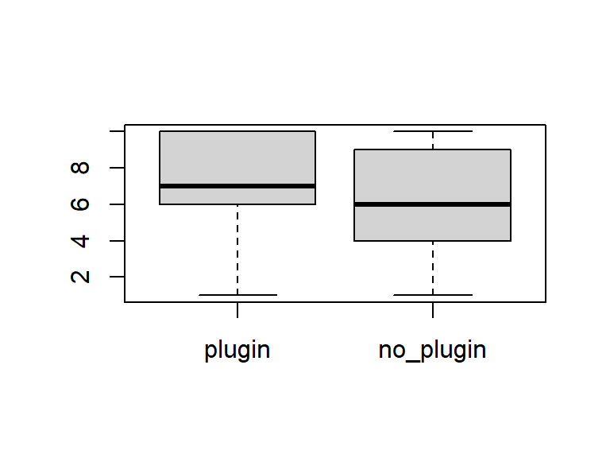

```r
boxplot(list(plugin = scores[scores$use_plugin == 1,]$score,
             no_plugin = scores[scores$use_plugin == 0,]$score))
```

The two groups are statistically indistinguishable:

```r
t.test(scores[scores$use_plugin == 1,]$score,
       scores[scores$use_plugin == 0,]$score)
```

```
##
##  Welch Two Sample t-test
##
## data:  scores[scores$use_plugin == 1, ]$score and scores[scores$use_plugin == 0, ]$score
## t = 1.5136, df = 227.21, p-value = 0.1315
## alternative hypothesis: true difference in means is not equal to 0
## 95 percent confidence interval:
##  -0.1586044  1.2096554
## sample estimates:
## mean of x mean of y
##  7.111111  6.585586
```

Visualize the two groups separately for each task:

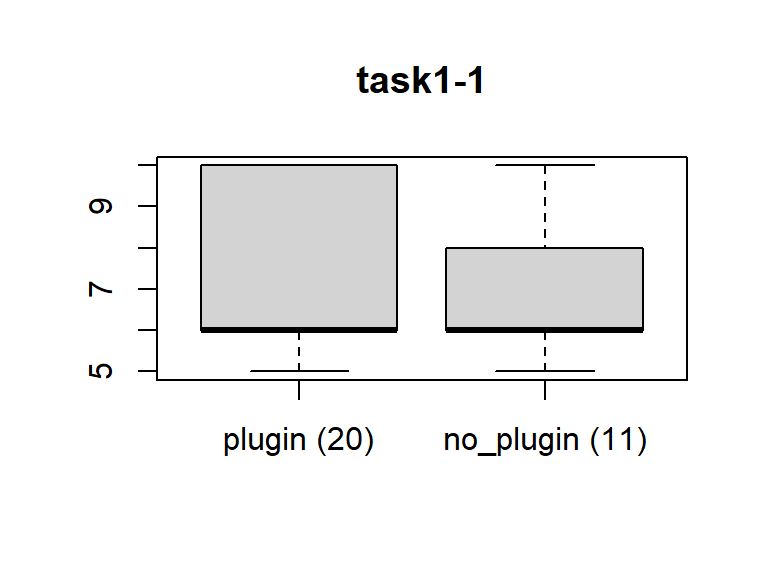

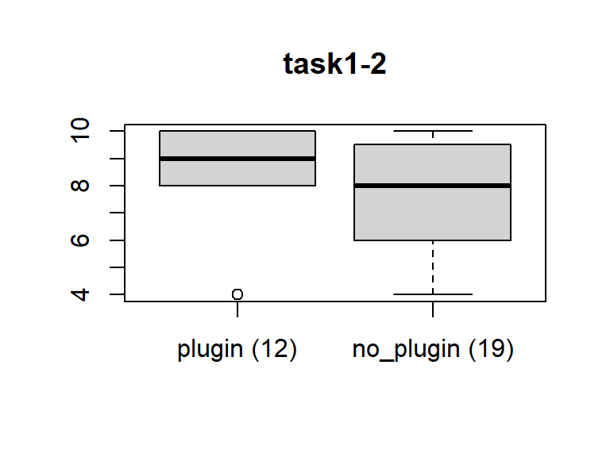

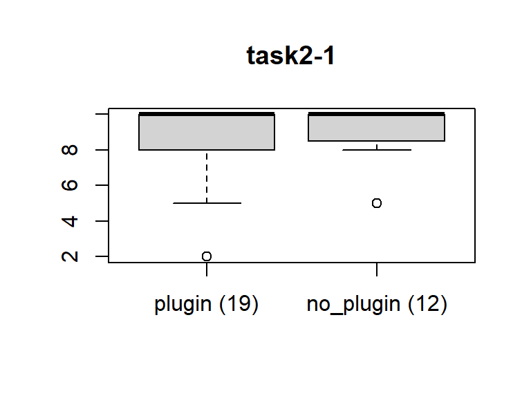

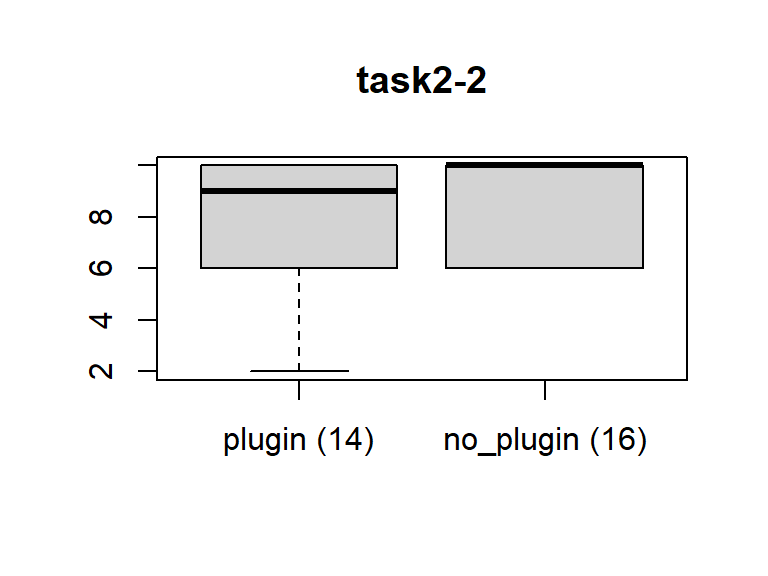

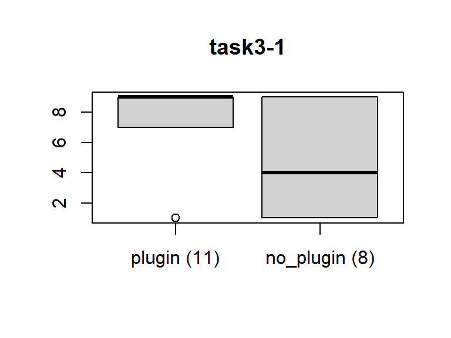

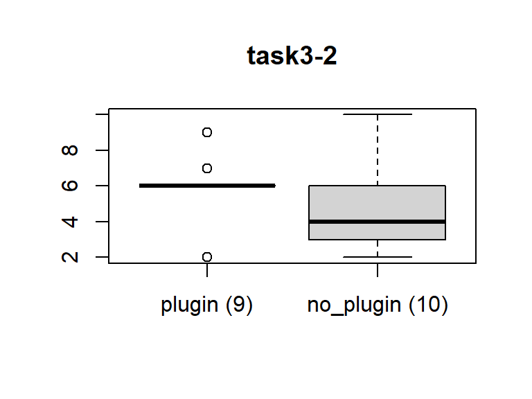

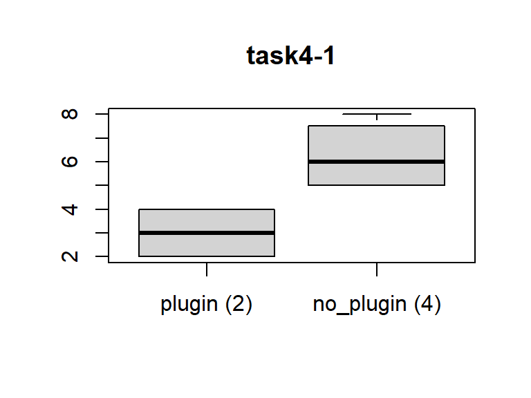

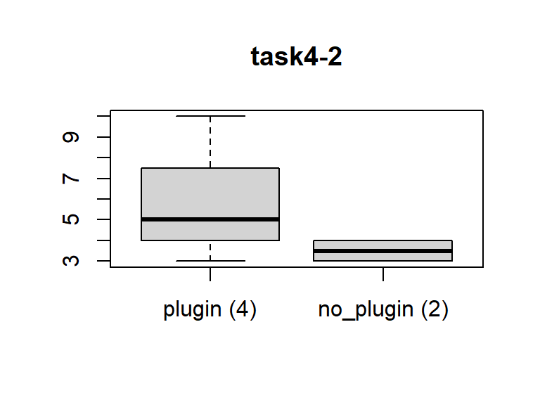

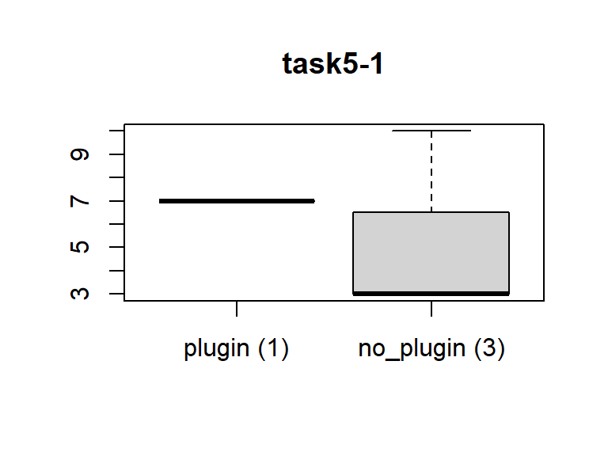

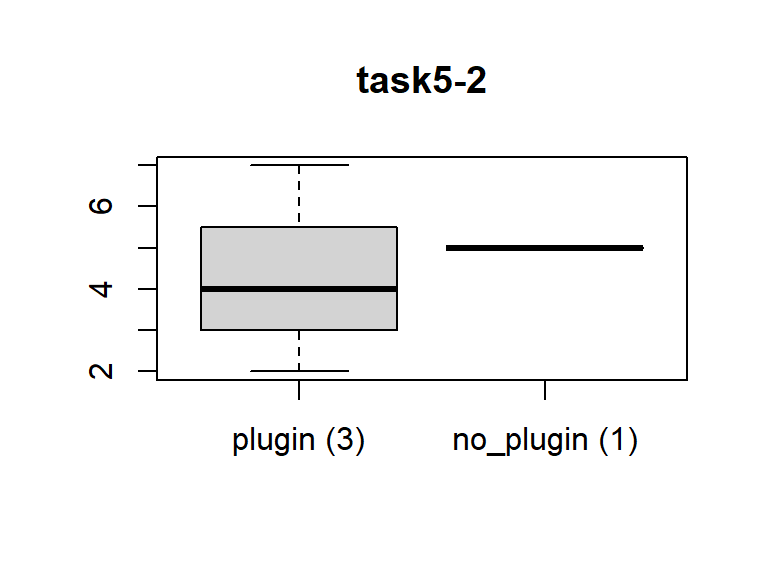

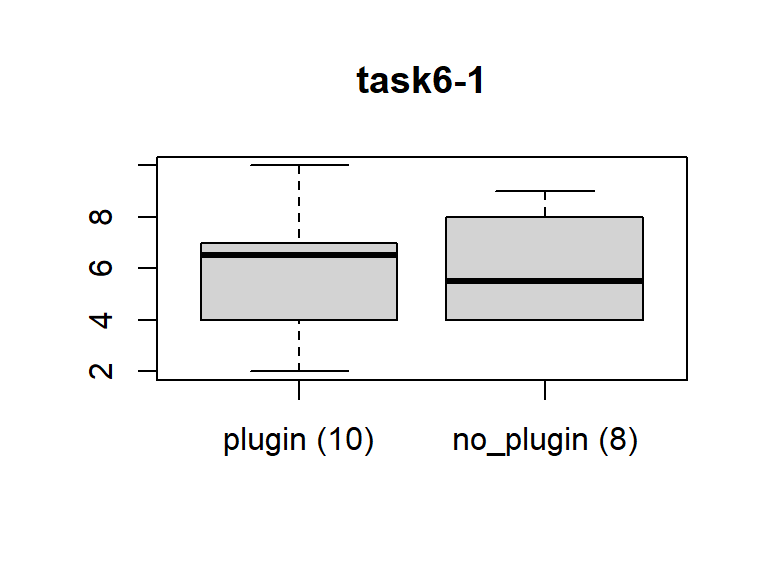

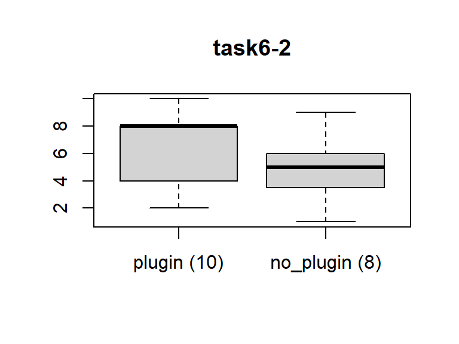

[2 more figures not shown]

```r
for (task in sort(unique(scores$task))) {
  plugin = scores[scores$task == task &
                    scores$use_plugin == 1,]$score
  no_plugin = scores[scores$task == task &
                       scores$use_plugin == 0,]$score
  boxplot(list(plugin = plugin,
               no_plugin = no_plugin),
          main = task,
          names = c(paste("plugin (", length(plugin), ")", sep = ""),
                    paste("no_plugin (", length(no_plugin), ")", sep = "")))
}
```

Test the two groups separately for each task:

```r
for (task in sort(unique(scores$task))) {
  plugin = completion_times[scores$task == task &
                              scores$use_plugin == 1,]$score
  no_plugin = completion_times[scores$task == task &
                                 scores$use_plugin == 0,]$score
  #t.test(plugin, no_plugin)
}
```

### Basic model: user and task as random effects

```r
m_ct0 = lmer(score ~
               +use_plugin
                 +
                 (1 | user)
                 +
                 (1 | task)
  , data = scores
  , REML = FALSE)
# vif(m_ct0)
summary(m_ct0)
```

```
## Linear mixed model fit by maximum likelihood . t-tests use Satterthwaite's
##   method [lmerModLmerTest]
## Formula: score ~ +use_plugin + (1 | user) + (1 | task)
##    Data: scores
##
##      AIC      BIC   logLik deviance df.resid
##   1104.7   1122.1   -547.4   1094.7      232
##
## Scaled residuals:
##     Min      1Q  Median      3Q     Max
## -2.6683 -0.6937  0.1266  0.6635  1.8136
##
## Random effects:
##  Groups   Name        Variance Std.Dev.
##  user     (Intercept) 0.6659   0.816
##  task     (Intercept) 1.3325   1.154
##  Residual             4.9526   2.225
## Number of obs: 237, groups:  user, 31; task, 14
##
## Fixed effects:
##                Estimate Std. Error       df t value Pr(>|t|)
## (Intercept)      6.1635     0.4156  26.1317  14.832 3.06e-14 ***
## use_pluginTRUE   0.4440     0.2977 205.4628   1.492    0.137
## ---
## Signif. codes:  0 '***' 0.001 '**' 0.01 '*' 0.05 '.' 0.1 ' ' 1
##
## Correlation of Fixed Effects:
##             (Intr)
## us_plgnTRUE -0.379
```

```r
model_parameters(m_ct0)
```

```
## Parameter      | Coefficient |   SE |        95% CI | t(232) |      p
## ---------------------------------------------------------------------
## (Intercept)    |        6.16 | 0.42 | [ 5.35, 6.98] |  14.83 | < .001
## use_pluginTRUE |        0.44 | 0.30 | [-0.14, 1.03] |   1.49 | 0.136
```

```r
r.squaredGLMM(m_ct0)
```

```
##              R2m       R2c
## [1,] 0.007041825 0.2925169
```

```r
Anova(m_ct0)
```

```
## Analysis of Deviance Table (Type II Wald chisquare tests)
##
## Response: score
##             Chisq Df Pr(>Chisq)
## use_plugin 2.2247  1     0.1358
```

Observations:

### Add task category experience as fixed effect

```r
m_ct1 = lmer(score ~
               task_experience
                 +
                 use_plugin
                 +
                 (1 | user)
                 +
                 (1 | task)
  , data = scores
  , REML = FALSE)
vif(m_ct1)
```

```
## task_experience      use_plugin
##         1.00073         1.00073
```

```r
summary(m_ct1)
```

```
## Linear mixed model fit by maximum likelihood . t-tests use Satterthwaite's
##   method [lmerModLmerTest]
## Formula: score ~ task_experience + use_plugin + (1 | user) + (1 | task)
##    Data: scores
##
##      AIC      BIC   logLik deviance df.resid
##   1104.2   1125.0   -546.1   1092.2      231
##
## Scaled residuals:
##     Min      1Q  Median      3Q     Max
## -2.6652 -0.6750  0.1357  0.6948  1.9038
##
## Random effects:
##  Groups   Name        Variance Std.Dev.
##  user     (Intercept) 0.6824   0.8261
##  task     (Intercept) 1.3718   1.1712
##  Residual             4.8777   2.2085
## Number of obs: 237, groups:  user, 31; task, 14
##
## Fixed effects:
##                 Estimate Std. Error       df t value Pr(>|t|)
## (Intercept)       7.4882     0.9275 182.4660   8.073 8.96e-14 ***
## task_experience  -0.3327     0.2074 216.2027  -1.604    0.110
## use_pluginTRUE    0.4551     0.2956 205.4475   1.539    0.125
## ---
## Signif. codes:  0 '***' 0.001 '**' 0.01 '*' 0.05 '.' 0.1 ' ' 1
##
## Correlation of Fixed Effects:
##             (Intr) tsk_xp
## task_exprnc -0.892
## us_plgnTRUE -0.144 -0.027
```

```r
model_parameters(m_ct1)
```

```
## Parameter       | Coefficient |   SE |        95% CI | t(231) |      p
## ----------------------------------------------------------------------
## (Intercept)     |        7.49 | 0.93 | [ 5.67, 9.31] |   8.07 | < .001
## task_experience |       -0.33 | 0.21 | [-0.74, 0.07] |  -1.60 | 0.109
## use_pluginTRUE  |        0.46 | 0.30 | [-0.12, 1.03] |   1.54 | 0.124
```

```r
r.squaredGLMM(m_ct1)
```

```
##             R2m       R2c
## [1,] 0.01687626 0.3082097
```

```r
anova(m_ct1, m_ct0)
```

```
## Data: scores
## Models:
## m_ct0: score ~ +use_plugin + (1 | user) + (1 | task)
## m_ct1: score ~ task_experience + use_plugin + (1 | user) + (1 | task)
##       npar    AIC    BIC  logLik deviance Chisq Df Pr(>Chisq)
## m_ct0    5 1104.8 1122.1 -547.37   1094.8
## m_ct1    6 1104.2 1125.0 -546.10   1092.2 2.546  1     0.1106
```

Observations:

- This model is not significantly better than the basic one.
- Still no effect for plugin use.

### De-mean task category experience, it may be confounded with user

```r
m_ct2 = lmer(score ~
               task_experience_between
                 +
                 task_experience_within
                 +
                 use_plugin
                 +
                 (1 | user)
                 +
                 (1 | task)
  , data = scores
  , control = lmerControl(optimizer = "Nelder_Mead")
  , REML = FALSE)
vif(m_ct2)
```

```
## task_experience_between  task_experience_within              use_plugin
##                1.000076                1.001198                1.001193
```

```r
summary(m_ct2)
```

```
## Linear mixed model fit by maximum likelihood . t-tests use Satterthwaite's
##   method [lmerModLmerTest]
## Formula:
## score ~ task_experience_between + task_experience_within + use_plugin +
##     (1 | user) + (1 | task)
##    Data: scores
## Control: lmerControl(optimizer = "Nelder_Mead")
##
##      AIC      BIC   logLik deviance df.resid
##   1105.6   1129.9   -545.8   1091.6      230
##
## Scaled residuals:
##     Min      1Q  Median      3Q     Max
## -2.6178 -0.6557  0.1373  0.6737  1.9420
##
## Random effects:
##  Groups   Name        Variance Std.Dev.
##  user     (Intercept) 0.6657   0.8159
##  task     (Intercept) 1.3575   1.1651
##  Residual             4.8758   2.2081
## Number of obs: 237, groups:  user, 31; task, 14
##
## Fixed effects:
##                          Estimate Std. Error        df t value Pr(>|t|)
## (Intercept)               6.35069    1.76268  35.60939   3.603 0.000953 ***
## task_experience_between  -0.05049    0.42593  33.99271  -0.119 0.906336
## task_experience_within   -0.41776    0.23616 201.59213  -1.769 0.078412 .
## use_pluginTRUE            0.46093    0.29560 205.59119   1.559 0.120464
## ---
## Signif. codes:  0 '***' 0.001 '**' 0.01 '*' 0.05 '.' 0.1 ' ' 1
##
## Correlation of Fixed Effects:
##             (Intr) tsk_xprnc_b tsk_xprnc_w
## tsk_xprnc_b -0.972
## tsk_xprnc_w -0.002  0.006
## us_plgnTRUE -0.094  0.006      -0.034
```

```r
model_parameters(m_ct2)
```

```
## Parameter               | Coefficient |   SE |        95% CI | t(230) |      p
## ------------------------------------------------------------------------------
## (Intercept)             |        6.35 | 1.76 | [ 2.90, 9.81] |   3.60 | < .001
## task_experience_between |       -0.05 | 0.43 | [-0.89, 0.78] |  -0.12 | 0.906
## task_experience_within  |       -0.42 | 0.24 | [-0.88, 0.05] |  -1.77 | 0.077
## use_pluginTRUE          |        0.46 | 0.30 | [-0.12, 1.04] |   1.56 | 0.119
```

```r
r.squaredGLMM(m_ct2)
```

```
##             R2m       R2c
## [1,] 0.01698526 0.3052551
```

```r
anova(m_ct2, m_ct0)
```

```
## Data: scores
## Models:
## m_ct0: score ~ +use_plugin + (1 | user) + (1 | task)
## m_ct2: score ~ task_experience_between + task_experience_within + use_plugin +
## m_ct2:     (1 | user) + (1 | task)
##       npar    AIC    BIC  logLik deviance  Chisq Df Pr(>Chisq)
## m_ct0    5 1104.8 1122.1 -547.37   1094.8
## m_ct2    7 1105.6 1129.9 -545.82   1091.6 3.1147  2     0.2107
```

Observations:

- This model is also not significantly better than the basic one.
- The same holds with a random slope (1 + task_experience_within | user).
- Still no effect for plugin use.

### Add Python experience

```r
m_ct3 = lmer(score ~
               python_experience
                 +
                 task_experience_between
                 +
                 task_experience_within
                 +
                 use_plugin
                 +
                 (1 | user)
                 +
                 (1 | task)
  , data = scores
  , REML = FALSE)
vif(m_ct3)
```

```
##       python_experience task_experience_between  task_experience_within
##                1.667127                1.666692                1.001217
##              use_plugin
##                1.001469
```

```r
summary(m_ct3)
```

```
## Linear mixed model fit by maximum likelihood . t-tests use Satterthwaite's
##   method [lmerModLmerTest]
## Formula:
## score ~ python_experience + task_experience_between + task_experience_within +
##     use_plugin + (1 | user) + (1 | task)
##    Data: scores
##
##      AIC      BIC   logLik deviance df.resid
##   1107.4   1135.1   -545.7   1091.4      229
##
## Scaled residuals:
##     Min      1Q  Median      3Q     Max
## -2.5889 -0.6624  0.1276  0.6736  1.9433
##
## Random effects:
##  Groups   Name        Variance Std.Dev.
##  user     (Intercept) 0.6515   0.8072
##  task     (Intercept) 1.3569   1.1649
##  Residual             4.8771   2.2084
## Number of obs: 237, groups:  user, 31; task, 14
##
## Fixed effects:
##                         Estimate Std. Error       df t value Pr(>|t|)
## (Intercept)               6.7086     1.8820  33.7759   3.565  0.00111 **
## python_experience        -0.2825     0.5383  31.3453  -0.525  0.60348
## task_experience_between   0.1308     0.5471  34.6624   0.239  0.81240
## task_experience_within   -0.4184     0.2362 201.5570  -1.772  0.07797 .
## use_pluginTRUE            0.4593     0.2957 205.5766   1.554  0.12183
## ---
## Signif. codes:  0 '***' 0.001 '**' 0.01 '*' 0.05 '.' 0.1 ' ' 1
##
## Correlation of Fixed Effects:
##             (Intr) pythn_ tsk_xprnc_b tsk_xprnc_w
## pythn_xprnc -0.363
## tsk_xprnc_b -0.472 -0.632
## tsk_xprnc_w -0.003  0.004  0.002
## us_plgnTRUE -0.095  0.017 -0.006      -0.034
```

```r
model_parameters(m_ct3)
```

```
## Parameter               | Coefficient |   SE |         95% CI | t(229) |      p
## -------------------------------------------------------------------------------
## (Intercept)             |        6.71 | 1.88 | [ 3.02, 10.40] |   3.56 | < .001
## python_experience       |       -0.28 | 0.54 | [-1.34,  0.77] |  -0.52 | 0.600
## task_experience_between |        0.13 | 0.55 | [-0.94,  1.20] |   0.24 | 0.811
## task_experience_within  |       -0.42 | 0.24 | [-0.88,  0.04] |  -1.77 | 0.076
## use_pluginTRUE          |        0.46 | 0.30 | [-0.12,  1.04] |   1.55 | 0.120
```

```r
r.squaredGLMM(m_ct3)
```

```
##             R2m       R2c
## [1,] 0.01879125 0.3049959
```

```r
anova(m_ct3, m_ct0)
```

```
## Data: scores
## Models:
## m_ct0: score ~ +use_plugin + (1 | user) + (1 | task)
## m_ct3: score ~ python_experience + task_experience_between + task_experience_within +
## m_ct3:     use_plugin + (1 | user) + (1 | task)
##       npar    AIC    BIC  logLik deviance  Chisq Df Pr(>Chisq)
## m_ct0    5 1104.8 1122.1 -547.37   1094.8
## m_ct3    8 1107.4 1135.1 -545.68   1091.4 3.3882  3     0.3356
```

```r
anova(m_ct3, m_ct2)
```

```
## Data: scores
## Models:
## m_ct2: score ~ task_experience_between + task_experience_within + use_plugin +
## m_ct2:     (1 | user) + (1 | task)
## m_ct3: score ~ python_experience + task_experience_between + task_experience_within +
## m_ct3:     use_plugin + (1 | user) + (1 | task)
##       npar    AIC    BIC  logLik deviance  Chisq Df Pr(>Chisq)
## m_ct2    7 1105.6 1129.9 -545.82   1091.6
## m_ct3    8 1107.4 1135.1 -545.68   1091.4 0.2735  1      0.601
```

Observations:

## Complexity Scores - CC (Cyclomatic Complexity)

### Descriptives

Number of entries in each group (plugin = 1):

```r
table(complexity_scores$use_plugin)
```

```
##
## FALSE  TRUE
##   111   126
```

Visualize all:

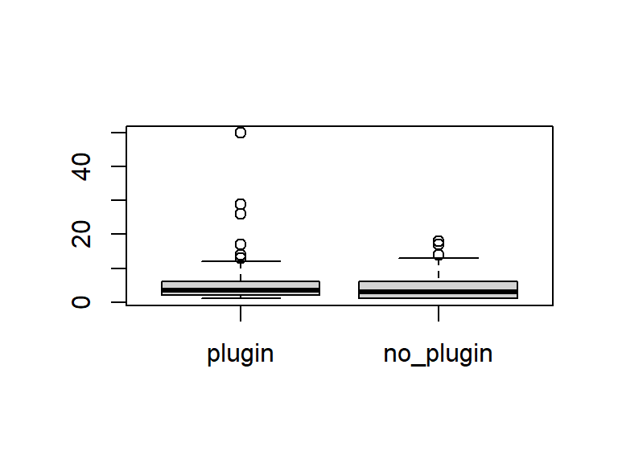

```r
boxplot(list(plugin = complexity_scores[complexity_scores$use_plugin == 1,]$cc,
             no_plugin = complexity_scores[complexity_scores$use_plugin == 0,]$cc))
```

The two groups are statistically indistinguishable:

```r
t.test(complexity_scores[complexity_scores$use_plugin == 1,]$cc,
       complexity_scores[complexity_scores$use_plugin == 0,]$cc)
```

```
##
##  Welch Two Sample t-test
##
## data:  complexity_scores[complexity_scores$use_plugin == 1, ]$cc and complexity_scores[complexity_scores$use_plugin == 0, ]$cc
## t = 1.3423, df = 206.49, p-value = 0.181
## alternative hypothesis: true difference in means is not equal to 0
## 95 percent confidence interval:
##  -0.4010771  2.1123598
## sample estimates:
## mean of x mean of y
##  5.134921  4.279279
```

Visualize the two groups separately for each task:

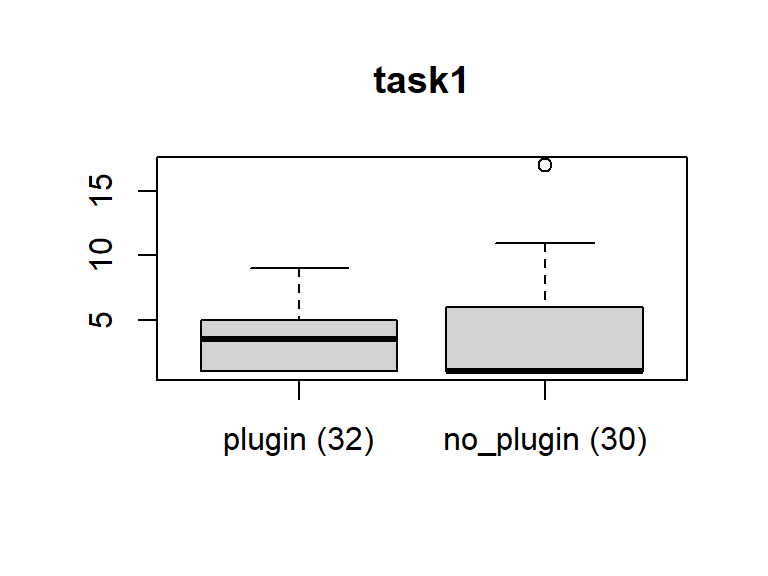

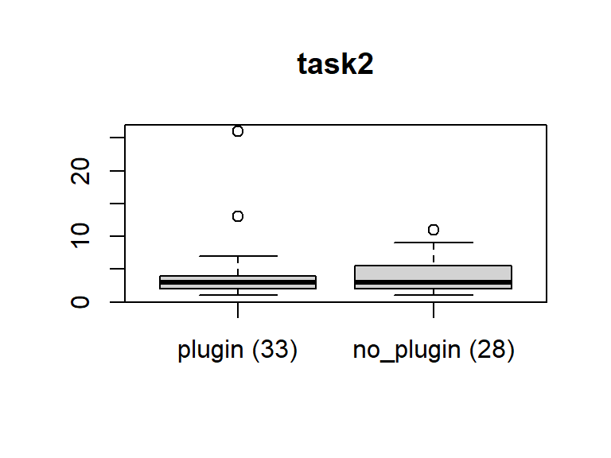

[figure not shown]

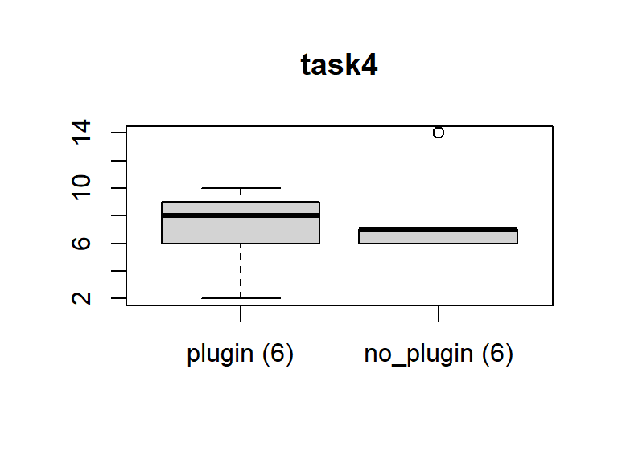

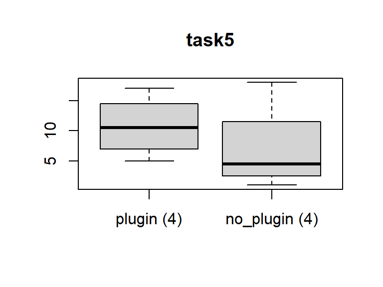

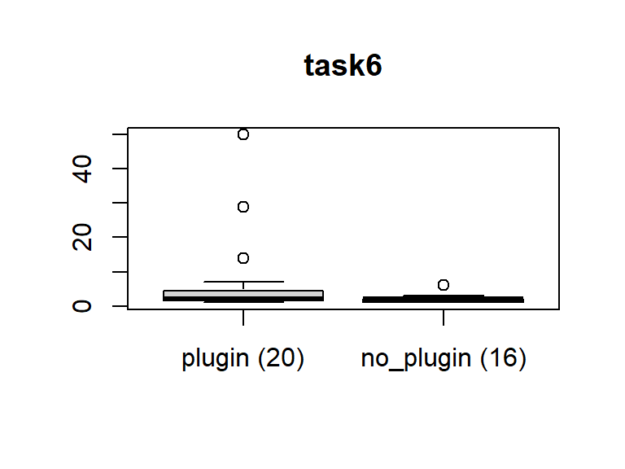

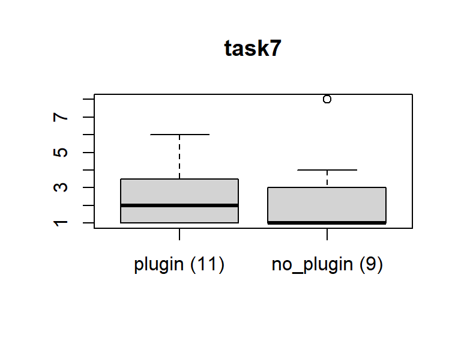

```r
for (category in sort(unique(complexity_scores$category))) {
  plugin = complexity_scores[complexity_scores$category == category &
                              complexity_scores$use_plugin == 1,]$cc
  no_plugin = complexity_scores[complexity_scores$category == category &
                                 complexity_scores$use_plugin == 0,]$cc
  boxplot(list(plugin = plugin,
               no_plugin = no_plugin),
          main = category,
          names = c(paste("plugin (", length(plugin), ")", sep = ""),
                    paste("no_plugin (", length(no_plugin), ")", sep = "")))
}
```

From the boxplots we see there’s not much data for tasks 4, 5, and 7.

### Basic model: user and task as random effects

```r
m_ct0 = lmer(cc ~
               +use_plugin
                 +
                 (1 | user)
                 +
                 (1 | task)
  , data = complexity_scores
  , REML = FALSE)
# vif(m_ct0)
summary(m_ct0)
```

```
## Linear mixed model fit by maximum likelihood . t-tests use Satterthwaite's
##   method [lmerModLmerTest]
## Formula: cc ~ +use_plugin + (1 | user) + (1 | task)
##    Data: complexity_scores
##
##      AIC      BIC   logLik deviance df.resid
##   1415.5   1432.8   -702.7   1405.5      232
##
## Scaled residuals:
##     Min      1Q  Median      3Q     Max
## -1.3543 -0.3609 -0.1213  0.1438  9.2997
##
## Random effects:
##  Groups   Name        Variance Std.Dev.
##  user     (Intercept)  1.362   1.167
##  task     (Intercept)  5.668   2.381
##  Residual             18.911   4.349
## Number of obs: 237, groups:  user, 31; task, 14
##
## Fixed effects:
##                Estimate Std. Error       df t value Pr(>|t|)
## (Intercept)      4.8415     0.8137  19.0503   5.950 9.88e-06 ***
## use_pluginTRUE   0.7339     0.5805 206.3809   1.264    0.208
## ---
## Signif. codes:  0 '***' 0.001 '**' 0.01 '*' 0.05 '.' 0.1 ' ' 1
##
## Correlation of Fixed Effects:
##             (Intr)
## us_plgnTRUE -0.377
```

```r
model_parameters(m_ct0)
```

```
## Parameter      | Coefficient |   SE |        95% CI | t(232) |      p
## ---------------------------------------------------------------------
## (Intercept)    |        4.84 | 0.81 | [ 3.25, 6.44] |   5.95 | < .001
## use_pluginTRUE |        0.73 | 0.58 | [-0.40, 1.87] |   1.26 | 0.206
```

```r
r.squaredGLMM(m_ct0)
```

```
##              R2m      R2c
## [1,] 0.005165374 0.274742
```

```r
Anova(m_ct0)
```

```
## Analysis of Deviance Table (Type II Wald chisquare tests)
##
## Response: cc
##             Chisq Df Pr(>Chisq)
## use_plugin 1.5987  1     0.2061
```

Observations:

## Complexity Scores - MI (Maintainability Index)

### Descriptives

Visualize all:

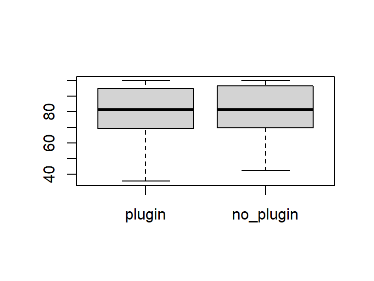

```r
boxplot(list(plugin = complexity_scores[complexity_scores$use_plugin == 1,]$mi,
             no_plugin = complexity_scores[complexity_scores$use_plugin == 0,]$mi))
```

The two groups are statistically indistinguishable:

```r
t.test(complexity_scores[complexity_scores$use_plugin == 1,]$mi,
       complexity_scores[complexity_scores$use_plugin == 0,]$mi)
```

```
##
##  Welch Two Sample t-test
##
## data:  complexity_scores[complexity_scores$use_plugin == 1, ]$mi and complexity_scores[complexity_scores$use_plugin == 0, ]$mi
## t = -0.56169, df = 234.39, p-value = 0.5749
## alternative hypothesis: true difference in means is not equal to 0
## 95 percent confidence interval:
##  -5.192079  2.888343
## sample estimates:
## mean of x mean of y
##  79.83990  80.99177
```

Visualize the two groups separately for each task:

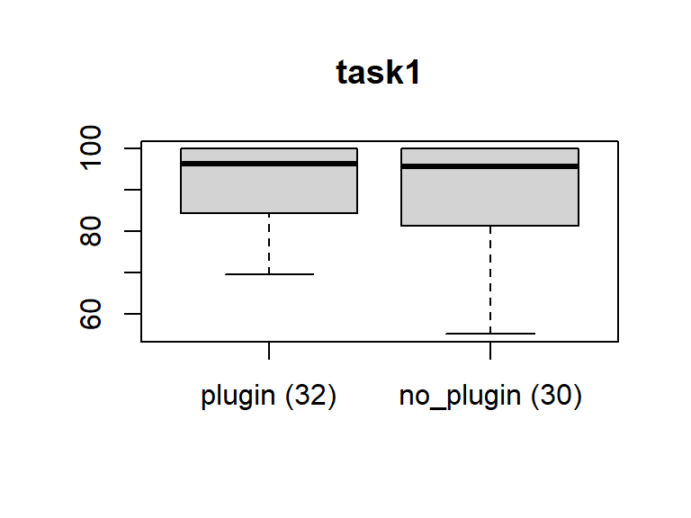

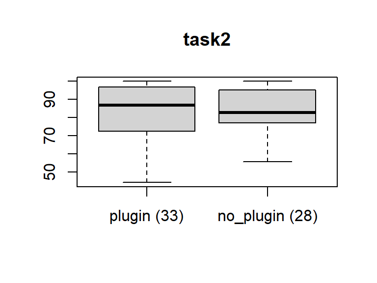

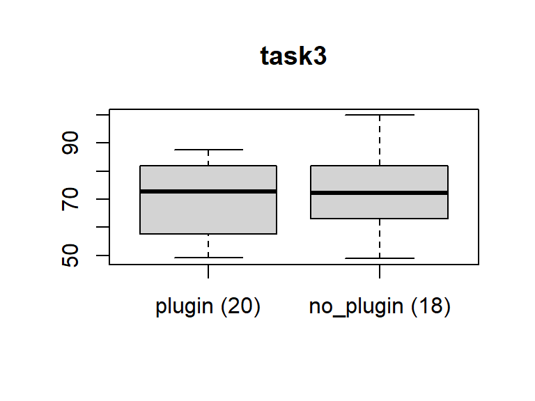

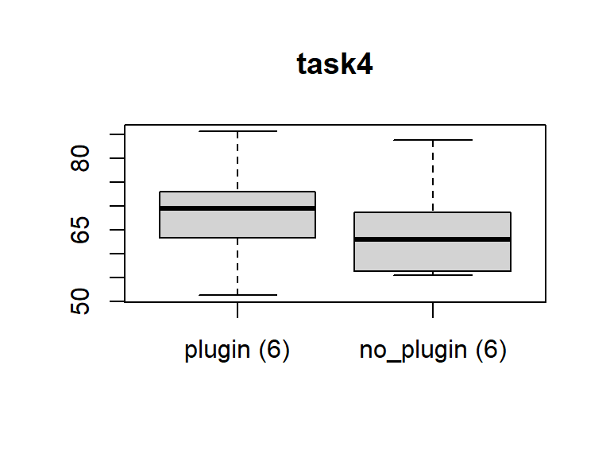

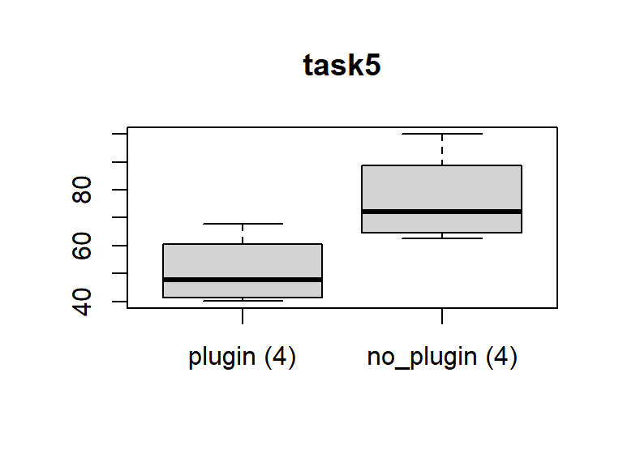

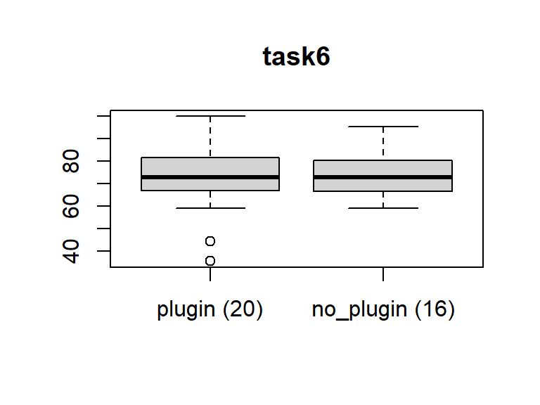

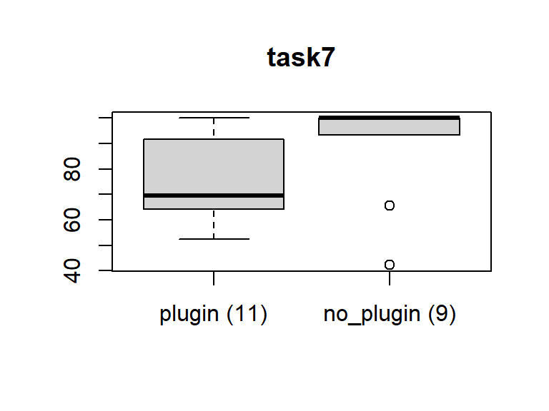

```r
for (category in sort(unique(complexity_scores$category))) {
  plugin = complexity_scores[complexity_scores$category == category &
                              complexity_scores$use_plugin == 1,]$mi
  no_plugin = complexity_scores[complexity_scores$category == category &
                                 complexity_scores$use_plugin == 0,]$mi
  boxplot(list(plugin = plugin,
               no_plugin = no_plugin),
          main = category,
          names = c(paste("plugin (", length(plugin), ")", sep = ""),
                    paste("no_plugin (", length(no_plugin), ")", sep = "")))
}
```

From the boxplots we see there’s not much data for tasks 4, 5, and 7.

### Basic model: user and task as random effects

```r
m_ct0 = lmer(mi ~
               +use_plugin
                 +
                 (1 | user)
                 +
                 (1 | task)
  , data = complexity_scores
  , REML = FALSE)
# vif(m_ct0)
summary(m_ct0)
```

```
## Linear mixed model fit by maximum likelihood . t-tests use Satterthwaite's
##   method [lmerModLmerTest]
## Formula: mi ~ +use_plugin + (1 | user) + (1 | task)
##    Data: complexity_scores
##
##      AIC      BIC   logLik deviance df.resid
##   1871.0   1888.3   -930.5   1861.0      232
##
## Scaled residuals:
##     Min      1Q  Median      3Q     Max
## -3.4288 -0.5671  0.1024  0.5830  2.7489
##
## Random effects:
##  Groups   Name        Variance Std.Dev.
##  user     (Intercept)  25.69    5.068
##  task     (Intercept) 130.17   11.409
##  Residual             112.47   10.605
## Number of obs: 237, groups:  user, 31; task, 14
##
## Fixed effects:
##                Estimate Std. Error       df t value Pr(>|t|)
## (Intercept)     76.6203     3.3905  17.4890  22.598 2.18e-14 ***
## use_pluginTRUE  -0.1972     1.4275 199.6788  -0.138     0.89
## ---
## Signif. codes:  0 '***' 0.001 '**' 0.01 '*' 0.05 '.' 0.1 ' ' 1
##
## Correlation of Fixed Effects:
##             (Intr)
## us_plgnTRUE -0.222
```

```r
model_parameters(m_ct0)
```

```
## Parameter      | Coefficient |   SE |         95% CI | t(232) |      p
## ----------------------------------------------------------------------
## (Intercept)    |       76.62 | 3.39 | [69.98, 83.27] |  22.60 | < .001
## use_pluginTRUE |       -0.20 | 1.43 | [-3.00,  2.60] |  -0.14 | 0.890
```

```r
r.squaredGLMM(m_ct0)
```

```
##               R2m       R2c
## [1,] 3.624493e-05 0.5808781
```

```r
Anova(m_ct0)
```

```
## Analysis of Deviance Table (Type II Wald chisquare tests)
##
## Response: mi
##             Chisq Df Pr(>Chisq)
## use_plugin 0.0191  1     0.8901
```

Observations: